# Lab 04 - Permutational Multivariate Tests

Nonparametric Statistics A.Y. 2025-2026

2025-10-17

```r
B = 5e3
seed = 20
```

## Permutational Multivariate Tests

In this part of the lab, we will directly implement some permutational multivariate tests, applied to specific problems Let’s start with our first one…

### Two multivariate populations test

We are given data of the week 12/09/2016 -> 18/09/2016 about the number of vehicles that, **each half-hour**, enter Milan Low emission zone (the so called “*area C*”). You want to know if the mean entrance pattern in the weekends is significantly different from the one in the weekdays. Framed in a more rigorous way, being

$$\mathbf{y}_{i,w} \overset{iid}{\sim} \mathbf{Y}_{w} \in \mathbb{R}^{48};
\, i \in \{1,...,5\}$$
where $w$ denotes the distribution of weekdays, and $i$ is the $i$th day of the week. We also have:
$$\mathbf{y}_{i,\tilde{w}} \overset{iid}{\sim} \mathbf{Y}_{\tilde{w}} \in
\mathbb{R}^{48} \; i \in \{6,7\}$$
where $\tilde{w}$ is to denote weekend day. We want to test the equality of the two distributions, namely, we want to devise a test of the type:
$$H_0: \mathbf{Y}_{w} \overset{d}{=}
\mathbf{Y}_{\tilde{w}}\;vs\;H_1:\mathbf{Y}_{w} \overset{d}{\neq}
\mathbf{Y}_{\tilde{w}}$$

Let’s start by reading and rearranging the data.

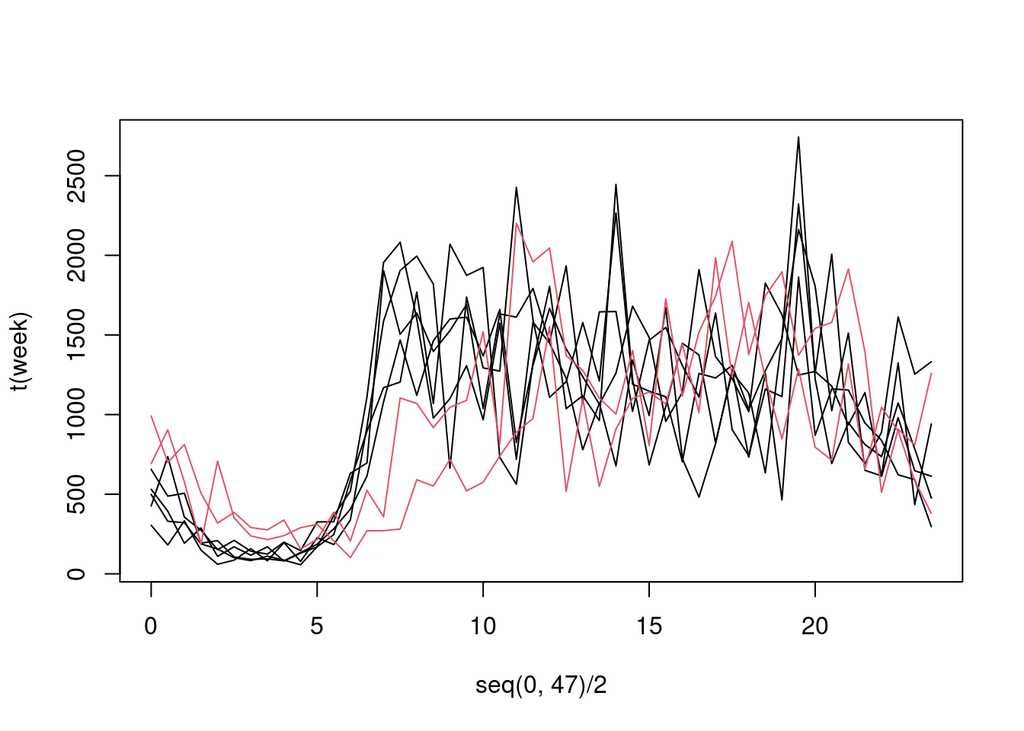

```r
# set header = TRUE read the first row in the csv as colnames.
# for every day, we will have observations corresponding to every half hour
d1 = read.csv('./data/areac_data/accessi-orari-areac-2016-09-12-00_00_00.csv', header=T)
d2 = read.csv('./data/areac_data/accessi-orari-areac-2016-09-13-00_00_00.csv', header=T)
d3 = read.csv('./data/areac_data/accessi-orari-areac-2016-09-14-00_00_00.csv', header=T)
d4 = read.csv('./data/areac_data/accessi-orari-areac-2016-09-15-00_00_00.csv', header=T)
d5 = read.csv('./data/areac_data/accessi-orari-areac-2016-09-16-00_00_00.csv', header=T)
d6 = read.csv('./data/areac_data/accessi-orari-areac-2016-09-17-00_00_00.csv', header=T)
d7 = read.csv('./data/areac_data/accessi-orari-areac-2016-09-18-00_00_00.csv', header=T)

# we bind the rows corresponding to every day.
week = rbind(d1[,2], d2[,2], d3[,2], d4[,2], d5[,2],
             d6[,2], d7[,2])
# plot
matplot(seq(0,47)/2, # every half-hour of the day
        t(week), # we want to plat the columns
        type='l',
        col=c(1,1,1,1,1,2,2), # colour weekdays and weekend-days differentlyy
        lty=1)
```

As you remember, we can actually choose whatever test statistic we may like: if the permutation scheme used during the test is likelihood-invariant, we will get in any case an exact test. There are nevertheless better choices than others (in the sense that we have a higher power, as we saw in the previous lab). Let’s try to use the squared euclidean distance between the two sample mean vectors (admittedly a quite standard choice.)

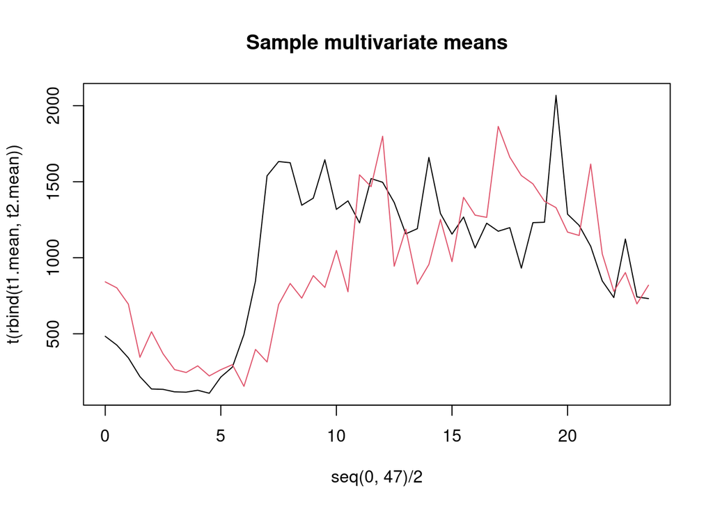

```r
t1 = week[1:5,]
t2 = week[6:7,]

t1.mean = colMeans(t1)
t2.mean = colMeans(t2)

matplot(seq(0,47)/2,
        t(rbind(t1.mean,t2.mean)),
        type='l', col=c(1,2), lty=1,
        main="Sample multivariate means")
```

Let’s compute the test statistic
$$T_0
=||\bar{\mathbf{x}}_1 -\bar{\mathbf{x}}_2||_2^2
=(\bar{\mathbf{x}}_1-\bar{\mathbf{x}}_2)^\intercal(\bar{\mathbf{x}}_1-\bar{\mathbf{x}}_2)$$
where $||.||_2$ denotes the euclidean norm in $\mathbb{R}^{48}$.

```r
n1 = dim(t1)[1]
n2 = dim(t2)[1]
n  = n1 + n2

T20 = as.numeric(t(t1.mean-t2.mean) %*% (t1.mean-t2.mean))  # matrix (vector) product
T20
```

```
## [1] 8976210
```

To perform our test, we need to compare the test statistic to its (permutational) distribution under $H_0$.

```r
# Estimating the permutational distribution under H0

T2 = numeric(B)
set.seed(seed)
for(perm in 1:B){
  # Random permutation of indexes
  # When we apply permutations in a multivariate case, we keep the units together
  # i.e., we only permute the rows of the data matrix
  t_pooled = rbind(t1,t2)
  permutation = sample(n)
  t_perm = t_pooled[permutation,]
  t1_perm = t_perm[1:n1,]
  t2_perm = t_perm[(n1+1):n,]

  # Evaluation of the test statistic on permuted data
  t1.mean_perm = colMeans(t1_perm)
  t2.mean_perm = colMeans(t2_perm)
  T2[perm]  = t(t1.mean_perm-t2.mean_perm) %*% (t1.mean_perm-t2.mean_perm)
}
```

Let’s now see the shape of the permutational distribution, compared with the computed test statistic (the green vertical line…)

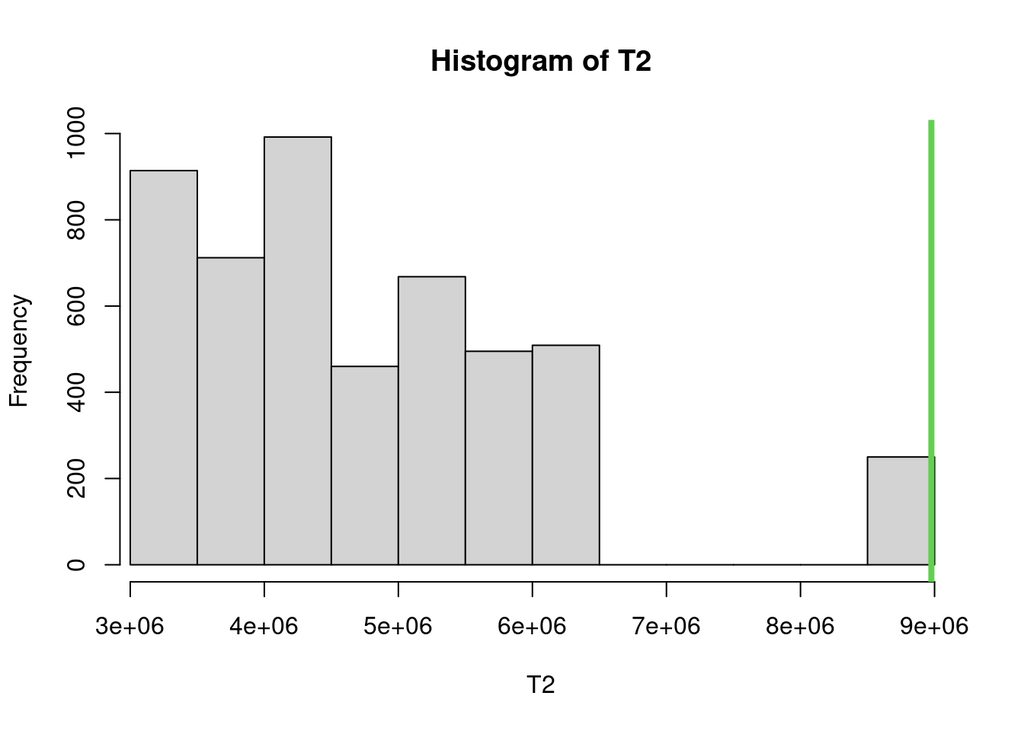

```r
hist(T2,xlim=range(c(T2,T20)))
abline(v=T20,col=3,lwd=4)
```

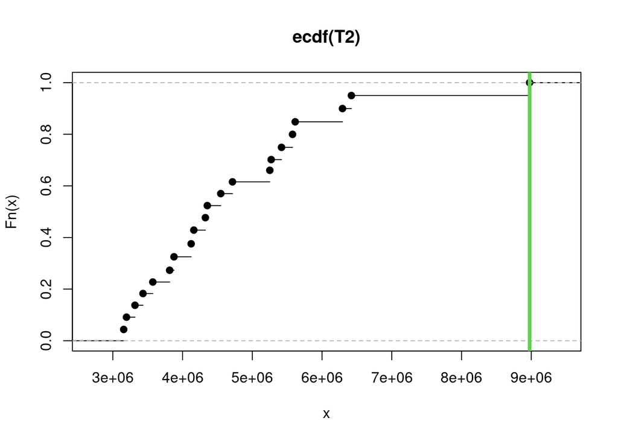

```r
plot(ecdf(T2))
abline(v=T20,col=3,lwd=4)
```

```r
p_val = sum(T2>=T20)/B
p_val
```

```
## [1] 0.05
```

let’s see another case now…

### Center of symmetry permutation tests

#### Multivariate case

We’re still in Milan, but now we want to check if the humidity of ($4$) summer months is significantly different from the “non-comfort” threshold level of $(65\%)$. *Id est*, are interested in the **location** of a (multivariate) distribution.

In other words, being ($i$ represents the sample’s $i$th datum )
$$\mathbf{y}_{i} \overset{iid}{\sim} \mathbf{Y} \in \mathbb{R}^{4}$$
, I want to test

$$H_0: \mathbb{E}[\mathbf{Y}] =
\mathbf{\mu}_{0}\;vs\;H_1:\mathbb{E}[\mathbf{Y}] \neq \mathbf{\mu}_0$$
Let’s read and plot the data also here. We will have 4 observations ($p=4$) for 7 different year ($n=7$).

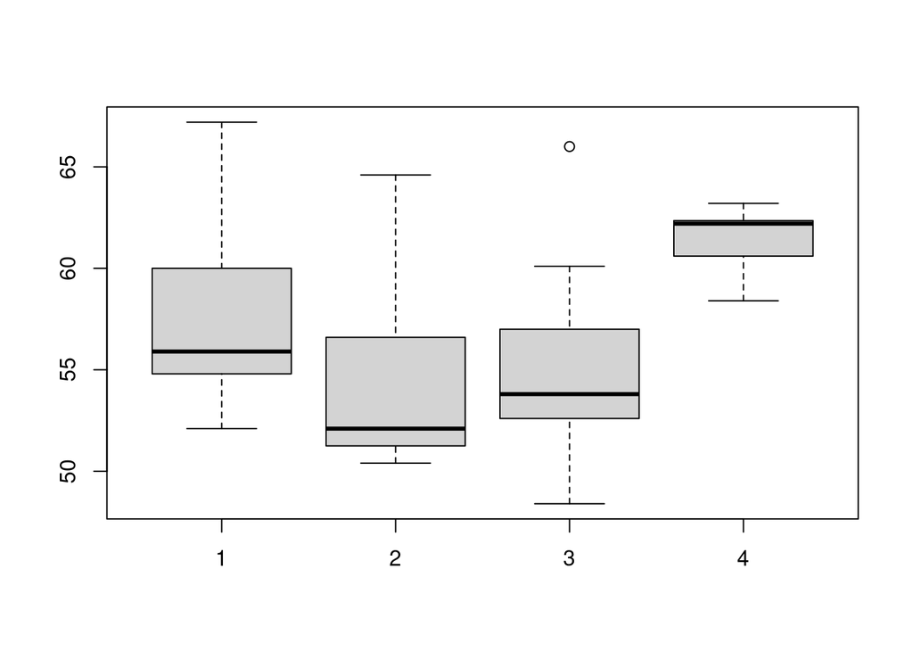

```r
hum = read.csv2('./data/humidity_data/307_Umidita_relativa_2008_2014.csv', header=T)
hum = hum$Media  # we use only the mean humidity
hum = matrix(hum,  # cast as matrix
             ncol=12, byrow=T)[,6:9] # so we have n = 7 and p =4

boxplot(hum)
```

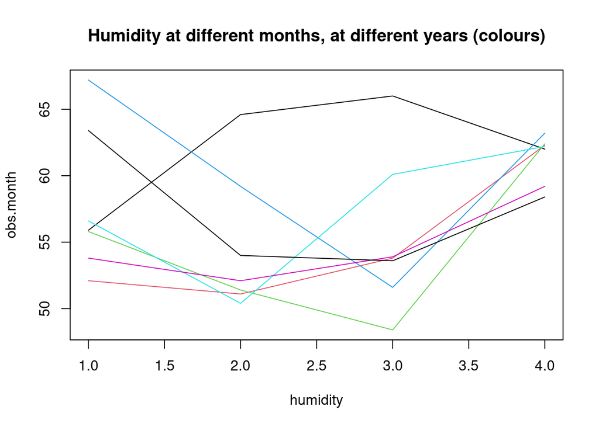

```r
matplot(t(hum),
        type='l',
        lty=1,
        main="Humidity at different months, at different years (colours)",
        xlab="humidity",
        ylab="obs.month")
```

What is a reasonable permutation scheme to implement, and thus what is a reasonable test to perform? It is actually harder with respect to two-sample tests… but if we **assume the distribution to be symmetric**, reflections are permutationally invariant, and thus I can easily test this! Let’s define the center of symmetry

```r
mu0      = c(65, 65, 65, 65)
```

Let’s compute the test statistic (here the squared distance between the sample mean and the hypothesised centre, but of course other choices are possible…)

```r
x.mean   = colMeans(hum)
n = dim(hum)[1]
p = dim(hum)[2]

T20 = as.numeric(t(x.mean-mu0) %*% (x.mean-mu0) )
```

And now, let’s compute the permutational distribution!

```r
T2 = numeric(B)
set.seed(20)

for(perm in 1:B){
  # In this case we use changes of signs in place of permutations

  # Permuted dataset (reflection-based)
  signs.perm = rbinom(n, 1, 0.5)*2 - 1
  hum_perm = mu0 + (hum - mu0) * matrix(signs.perm, nrow=n,ncol=p,byrow=FALSE)  # hadamard product
  x.mean_perm = colMeans(hum_perm)
  T2[perm]  = t(x.mean_perm-mu0)  %*% (x.mean_perm-mu0) #n.b. also works without the t, but better to play it safe!
}
```

let’s plot the permutational distribution of the test statistic

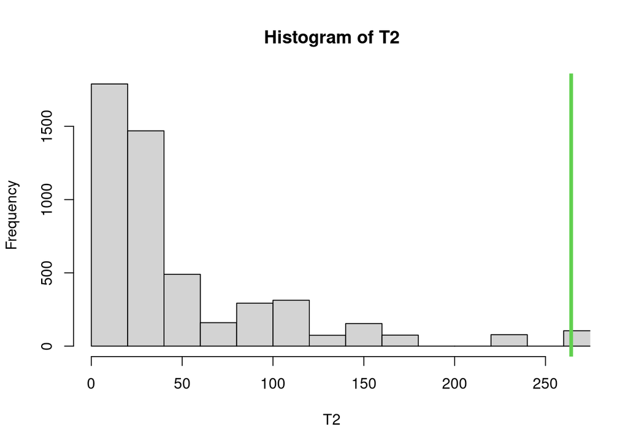

```r
hist(T2,xlim=range(c(T2,T20)))
abline(v=T20,col=3,lwd=4)
```

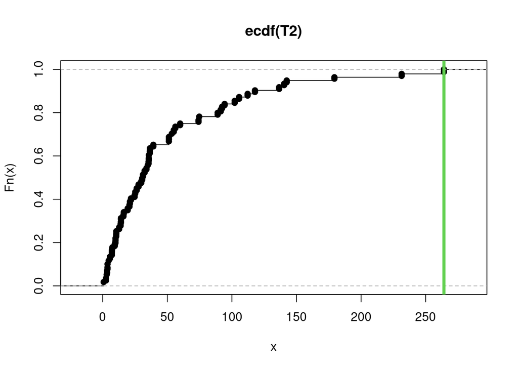

```r
plot(ecdf(T2))
abline(v=T20,col=3,lwd=4)
```

and the p-value

```r
p_val <- sum(T2>=T20)/B
p_val
```

```
## [1] 0.021
```

Also here, I can argue that the humidity during the summer months is, with a 95% level of confidence ( *i.e.* 5% of the times I will reject $H_0$ when it is actually true), significantly different from $65%$

#### Univariate case

Of course this generalises the univariate case. We might take the observed humidity at only one month (univariate), and different years are (independent) observations.

In terms of code, this is looking at one column of the matrix.

```r
x.mean  <- mean(hum[,1])
mu.0 <- 65
n = dim(hum)[1]
p = 1

T20 = (x.mean - mu.0)^2

T2 = numeric(B)
set.seed(20)

for(perm in 1:B){
  # In this case we use changes of signs in place of permutations

  # Permuted dataset (reflection-based)
  signs.perm = rbinom(n, 1, 0.5)*2 - 1
  hum_perm = as.vector(mu.0 + (hum[,1] - mu.0) * matrix(signs.perm, nrow=n,ncol=1,byrow=FALSE))  # hadamard product
  x.mean_perm = mean(hum_perm)
  T2[perm]  = (x.mean_perm-mu.0)**2
}
```

And we look at the (MC-estimated) permutational distribution of the test statistic under $H_0$

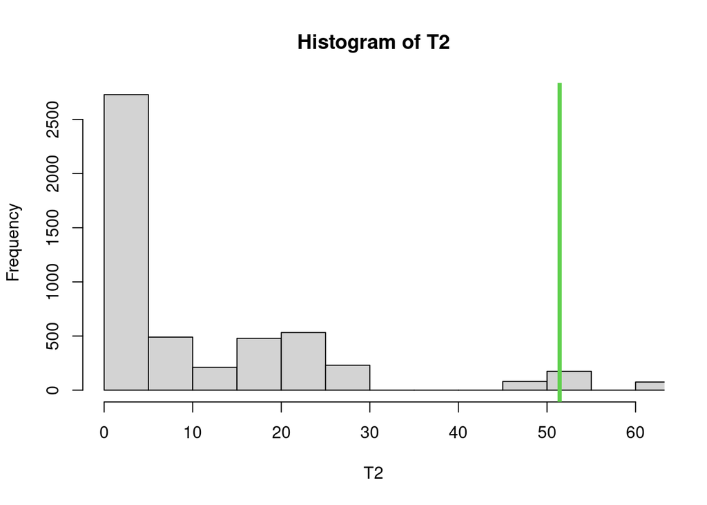

```r
hist(T2,xlim=range(c(T2,T20)))
abline(v=T20,col=3,lwd=4)
```

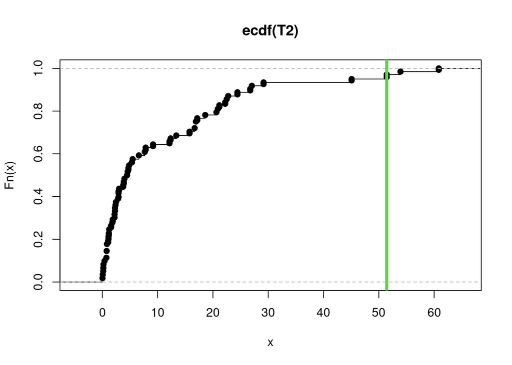

```r
plot(ecdf(T2))
abline(v=T20,col=3,lwd=4)
```

and the p-value

```r
p_val <- sum(T2>=T20)/B
p_val
```

```
## [1] 0.0498
```

### Two sample paired multivariate permutation test

#### Option 1

We test:
$$H_0 : \mathbb{E}[X_M-X_B] = \mathbf{0} \, versus \, H_1:
\mathbb{E}[X_M-X_B] \neq \mathbf{0}$$

Let’s read the data

```r
t1 <- read.table('./data/meteo_data/barcellona.txt', header=T)
t2 <- read.table('./data/meteo_data/milano.txt', header=T)
```

Let’s try to explore the data… we can work with the paired differences and plot them.

```r
library(rgl)
open3d()
```

```
## glX
##   1
```

```r
plot3d(t1-t2, size=3, col='orange', aspect = F)
points3d(0,0,0, size=6)

p  <- dim(t1)[2]
n1 <- dim(t1)[1]
n2 <- dim(t2)[1]
n <- n1+n2
```

In terms of permutation schemes (and testing strategies…) to follow, the best choice is to compute the differences between the two groups, assume their distribution to be symmetric, and then perform a centre of symmetry test.

What is the best test statistic for the test? let’s see…

```r
t1.mean <- colMeans(t1)
t2.mean <- colMeans(t2)
t1.cov  <-  cov(t1)
t2.cov  <-  cov(t2)
Sp      <- ((n1-1)*t1.cov + (n2-1)*t2.cov)/(n1+n2-2)  # pooled cov matrix
Spinv   <- solve(Sp)

delta.0 <- c(0,0,0)

diff <- t1-t2
diff.mean <- colMeans(diff)
diff.cov <- cov(diff)
diff.invcov <- solve(diff.cov)
```

Let’s start with the squared euclidean distance between the difference in means and the hypothesised value

```r
T20 <- as.numeric(t(diff.mean-delta.0)  %*% (diff.mean-delta.0))
```

And then, let’s perform the test

```r
T2 <- numeric(B)
set.seed(seed)
for(perm in 1:B)
  {
  # Random permutation
  # obs: exchanging data within couples means changing the sign of the difference
  signs.perm <- rbinom(n1, 1, 0.5)*2 - 1

  diff_perm <- diff * matrix(signs.perm,nrow=n1,ncol=p,byrow=FALSE)
  diff.mean_perm <- colMeans(diff_perm)
  diff.cov_perm <- cov(diff_perm)
  diff.invcov_perm <- solve(diff.cov_perm)

  T2[perm] <- as.numeric(t(diff.mean_perm-delta.0) %*% (diff.mean_perm-delta.0))
  }
```

Distribution and pvalue

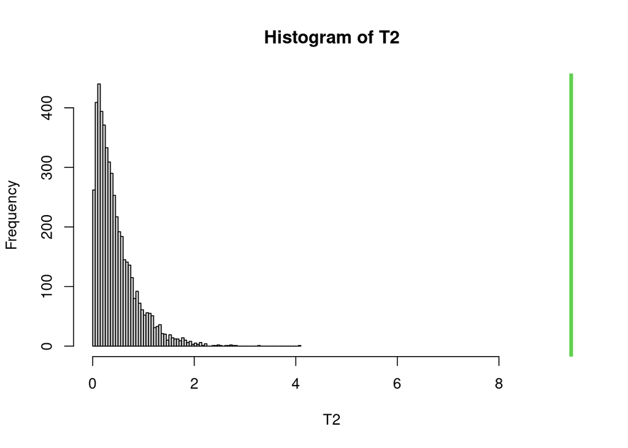

```r
# plotting the permutational distribution under H0
hist(T2,xlim=range(c(T2,T20)),breaks=100)
abline(v=T20,col=3,lwd=4)
```

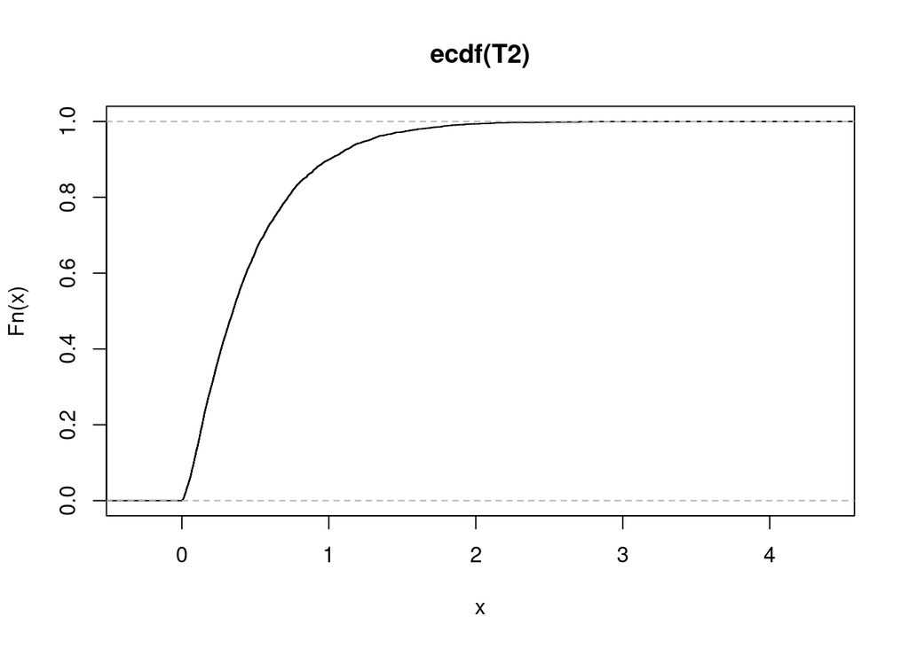

```r
plot(ecdf(T2))
abline(v=T20,col=3,lwd=4)
```

```r
# p-value
p_val <- sum(T2>=T20)/B
p_val
```

```
## [1] 0
```

Now, let’s use the Mahalanobis distance, but “forgetting” about the covariance between the values

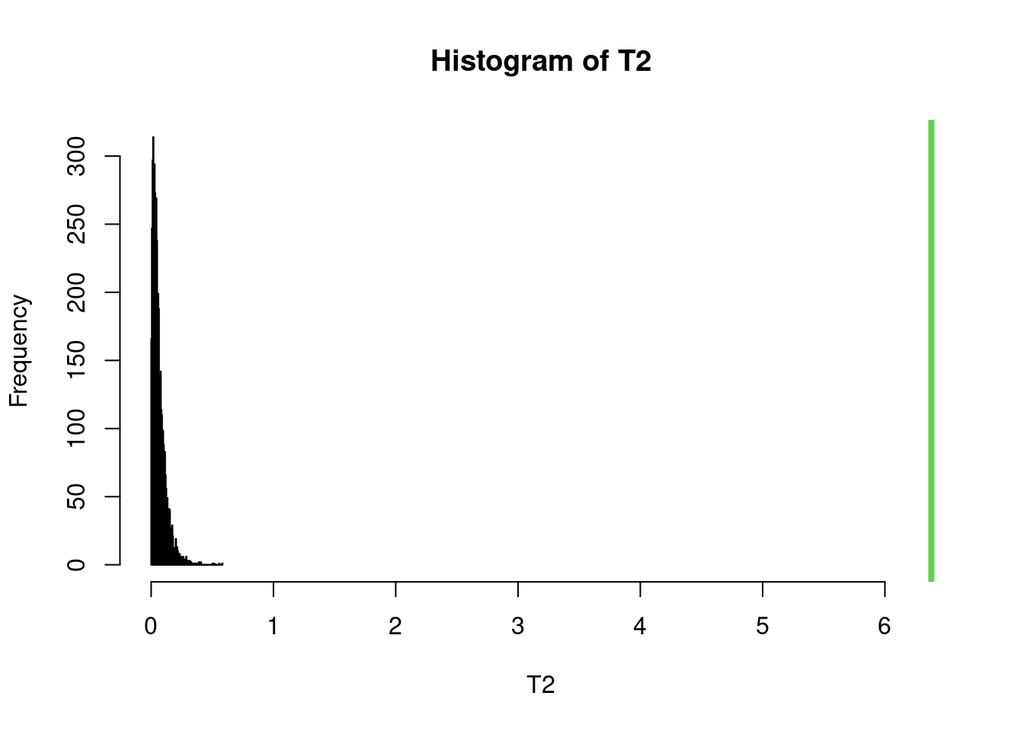

```r
T20 <- as.numeric( t(diff.mean-delta.0) %*% solve(diag(diag(diff.cov))) %*% (diff.mean-delta.0))
# Estimating the permutational distribution under H0
T2 <- numeric(B)
set.seed(seed)
for(perm in 1:B)
  {
  # Random permutation
  # obs: exchanging data within couples means changing the sign of the difference
  signs.perm <- rbinom(n1, 1, 0.5)*2 - 1

  diff_perm <- diff * matrix(signs.perm,nrow=n1,ncol=p,byrow=FALSE)
  diff.mean_perm <- colMeans(diff_perm)
  diff.cov_perm <- cov(diff_perm)
  diff.invcov_perm <- solve(diff.cov_perm)


  T2[perm] <- as.numeric((diff.mean_perm-delta.0) %*% solve(diag(diag(diff.cov_perm))) %*% (diff.mean_perm-delta.0))

}

# plotting the permutational distribution under H0
hist(T2,xlim=range(c(T2,T20)),breaks=100)
abline(v=T20,col=3,lwd=4)
```

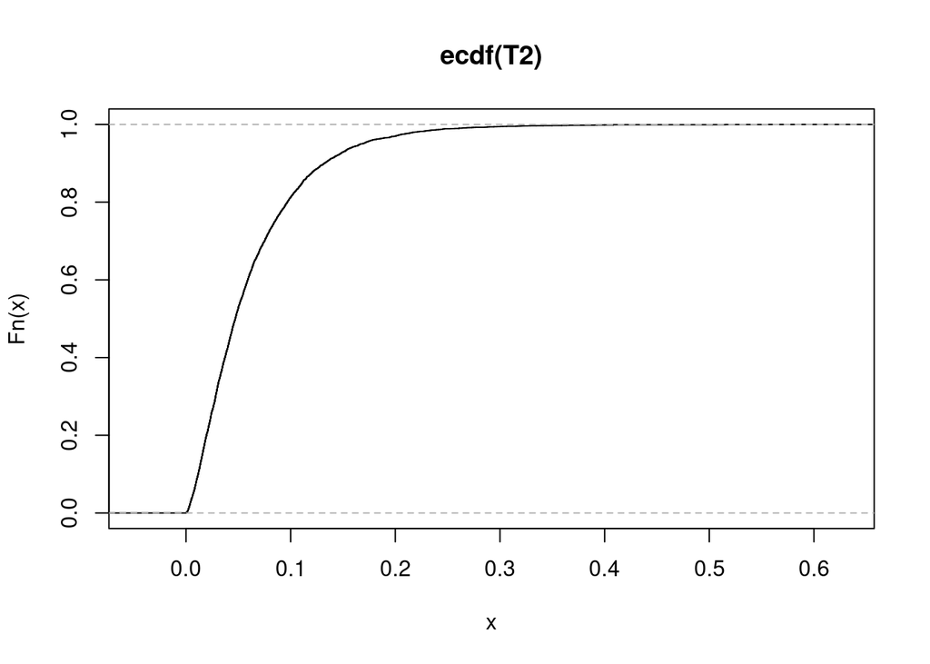

```r
plot(ecdf(T2))
abline(v=T20,col=3,lwd=4)
```

```r
# p-value
p_val <- sum(T2>=T20)/B
p_val
```

```
## [1] 0
```

and lastly, let’s use the proper Mahalanobis distance

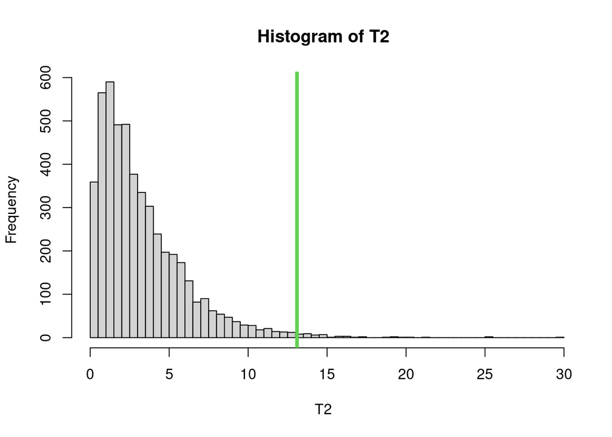

```r
T20 <- as.numeric((diff.mean-delta.0) %*% diff.invcov %*% (diff.mean-delta.0))



# Estimating the permutational distribution under H0

set.seed(seed)
T2 <- numeric(B)

for(perm in 1:B)
  {
  # Random permutation
  # obs: exchanging data within couples means changing the sign of the difference
  signs.perm <- rbinom(n1, 1, 0.5)*2 - 1

  diff_perm <- diff * matrix(signs.perm,nrow=n1,ncol=p,byrow=FALSE)
  diff.mean_perm <- colMeans(diff_perm)
  diff.cov_perm <- cov(diff_perm)
  diff.invcov_perm <- solve(diff.cov_perm)

  #T2[perm] <- as.numeric(n1 * (diff.mean_perm-delta.0) %*% (diff.mean_perm-delta.0))
  #T2[perm] <- as.numeric(n1 * (diff.mean_perm-delta.0) %*% solve(diag(diag(diff.cov_perm))) %*% (diff.mean_perm-delta.0))
  T2[perm] <- as.numeric(n1 * (diff.mean_perm-delta.0) %*% diff.invcov_perm %*% (diff.mean_perm-delta.0))
  }

# plotting the permutational distribution under H0
hist(T2,xlim=range(c(T2,T20)),breaks=100)
abline(v=T20,col=3,lwd=4)
```

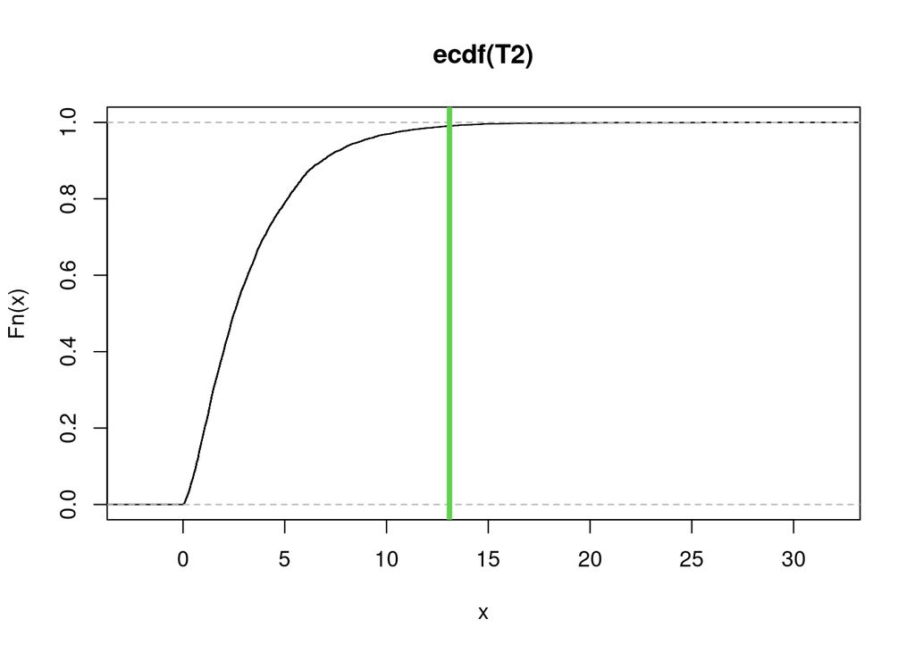

```r
plot(ecdf(T2))
abline(v=T20,col=3,lwd=4)
```

```r
# p-value
p_val <- sum(T2>=T20)/B
p_val
```

```
## [1] 0.0094
```

#### Option 2

If you read the *dispensa* created by Professor Alessia Pini[^1], you would find an alternative for this test.

Instead of performing inference on the distribution of
$$X_M - X_B$$
we treat them “separately”: $(X_M, X_B) \sim F$ for some **bivariate** distribution $F$. And of course we require likelihood-invariant transformations under $H_0$ that respect the paired nature of the test. We test:
$$H_0: X_M \stackrel{d}{=} X_B \; vs. \;H_1: X_M \stackrel{d}{\neq} X_B$$
And we have $2^N$ different permutations, since the **exchangeability is only within the pairs**. We choose as test statistic the norm of the differences of the means of both samples.

```r
T20 <- norm(as.matrix(colMeans(t1) - apply(t2, MARGIN=2, FUN=mean)))
```

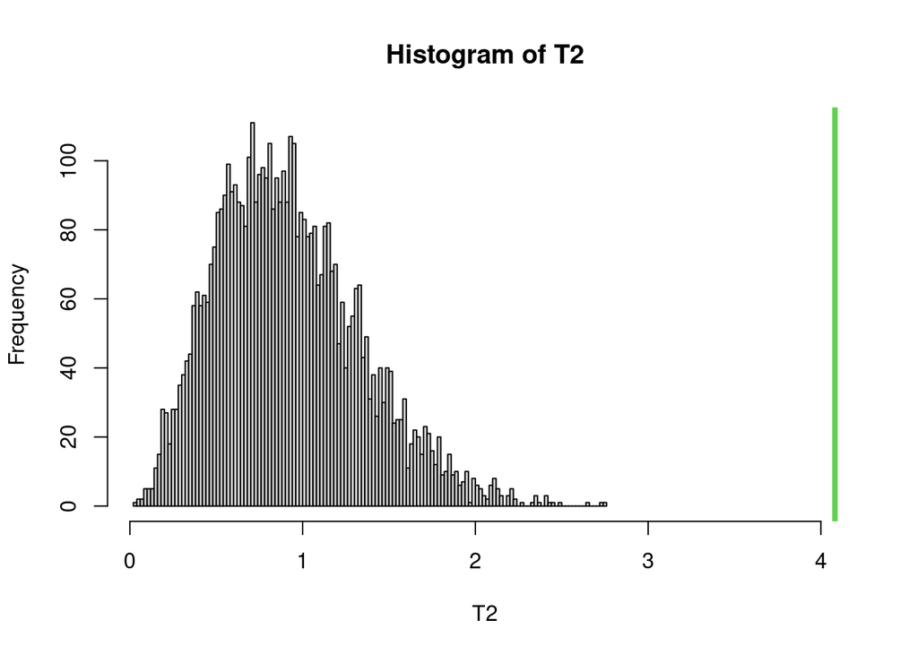

```r
T2 <- numeric(B)
p <- dim(t1)[2] # here naturally I can use t1 or t2.
n <- dim(t2)[1]
t.full <- rbind(t1, t2)
set.seed(seed)
for(perm in 1:B)
  {
  # Random permutation
  # N.B. exchangeability is only within pairs
  perm.indices.t1 <- seq(1, n) + n * rbinom(n,1, 0.5)
  t1.perm <- t.full[perm.indices.t1, ]
  t2.perm <- t.full[-perm.indices.t1,]

  T2[perm] <- norm(as.matrix(((colMeans(t1.perm)) - colMeans(t2.perm))))
}

hist(T2,xlim=range(c(T2,T20)),breaks=100)
abline(v=T20,col=3,lwd=4)
```

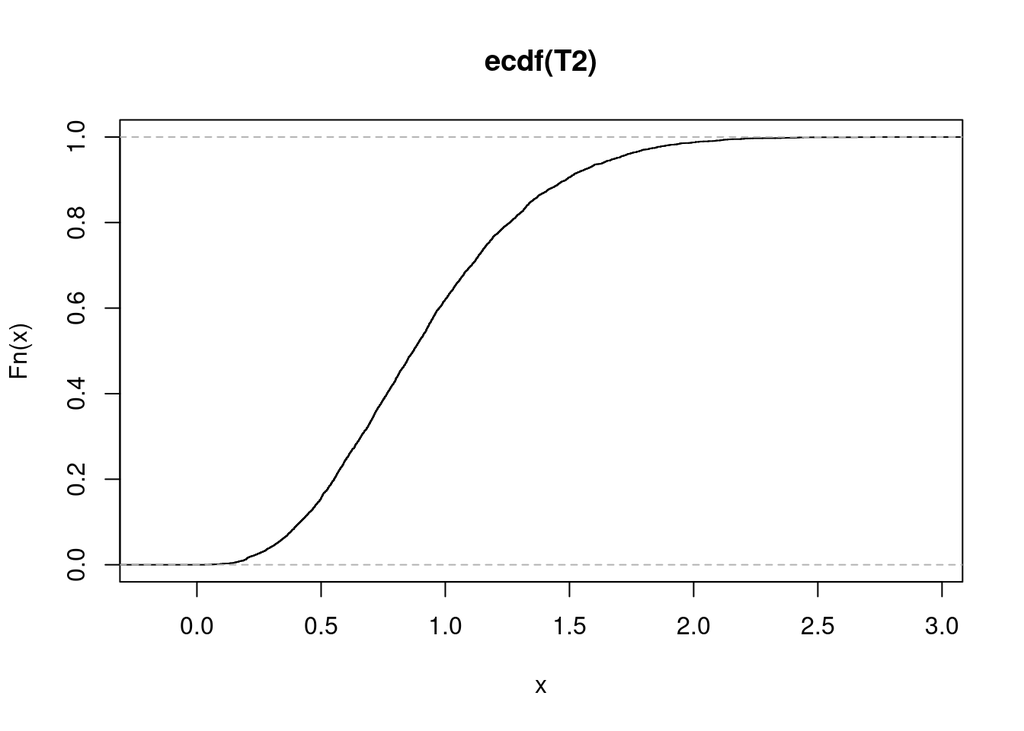

```r
plot(ecdf(T2))
abline(v=T20,col=3,lwd=4)
```

```r
# p-value
p_val <- sum(T2>=T20)/B
p_val
```

```
## [1] 0
```

## Permutational regression: categorical regressors

### Permutational ANOVA

Until now, we have seen how to perform basic statistical tests in a nonparametric and, mainly and more importantly, in a permutational framework. By going further on this line of thinking, one can perform analysis of variance in a fully permutational (and thus exact…) setting. The example we will see today is about a fairly old dataset, appeared on Biometrika in 1948 (!!). It is about an experiment over a number of chickens, fed with different feed types, which were weighted by the experimenter. You are interested in determining if the feed type has an impact on the chicken weight or not.

Let’s import and summarise the dataset

```r
chickwts
```

| weight | feed |
| --- | --- |
| 179 | horsebean |
| 160 | horsebean |
| 136 | horsebean |
| 227 | horsebean |
| 217 | horsebean |
| 168 | horsebean |
| 108 | horsebean |
| 124 | horsebean |
| 143 | horsebean |
| 140 | horsebean |

[output cut: 61 more lines]

```r
attach(chickwts)
summary(chickwts)
```

```
##      weight             feed
##  Min.   :108.0   casein   :12
##  1st Qu.:204.5   horsebean:10
##  Median :258.0   linseed  :12
##  Mean   :261.3   meatmeal :11
##  3rd Qu.:323.5   soybean  :14
##  Max.   :423.0   sunflower:12
```

and, let’s try to plot the results, to get a bit of info about what’s going on…

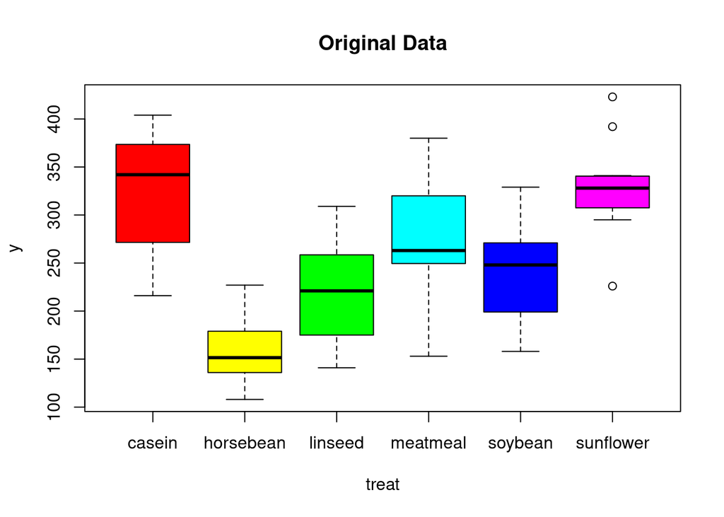

```r
g <- nlevels(feed)
n <- dim(chickwts)[1]

plot(feed, weight, xlab='treat',col=rainbow(g),main='Original Data')
```

The null hypothesis that we want to test is that, being $\tau_i, i\in \{1,\ldots6\}$ the generic effect of a given level of the treatment.
$$H_0: \tau_i=0\;\forall i\;vs\;H_1:\exists\,\tau_i\neq0$$

Of course we can solve this in a fully parametric (and admittedly not robust…) way

```r
fit <- aov(weight ~ feed)
summary(fit)
```

```
##             Df Sum Sq Mean Sq F value   Pr(>F)
## feed         5 231129   46226   15.37 5.94e-10 ***
## Residuals   65 195556    3009
## ---
## Signif. codes:  0 '***' 0.001 '**' 0.01 '*' 0.05 '.' 0.1 ' ' 1
```

The strategy that I use to perform permutational ANOVA is to “permutationalise” the F statistic, by computing its permutational distribution under $H_0$. So…

```r
T0 <- summary(fit)[[1]][1,4]  # extract the test statistic
T0
```

```
## [1] 15.3648
```

To compute the distribution, one simply “scales up” the one used for the 2-sample t-test: I assign at random the treatments (that, under $H_0$, should all be equal, and equal to 0)

```r
T_stat <- numeric(B)
n <- dim(chickwts)[1]

for(perm in 1:B){
  # Permutation:
  permutation <- sample(1:n)
  weight_perm <- weight[permutation]
  fit_perm <- aov(weight_perm ~ feed)

  # Test statistic:
  T_stat[perm] <- summary(fit_perm)[[1]][1,4]
}
```

Let’s see the distribution, and then the p-value of the permutational f-test

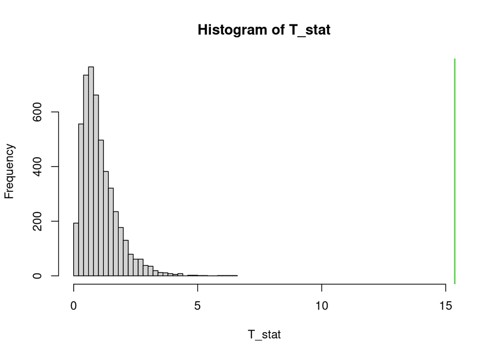

```r
hist(T_stat,xlim=range(c(T_stat,T0)),breaks=30)
abline(v=T0,col=3,lwd=2)
```

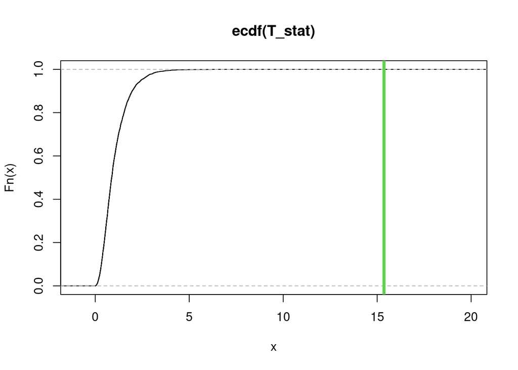

```r
plot(ecdf(T_stat),xlim=c(-1,20))
abline(v=T0,col=3,lwd=4)
```

```r
# p-value
p_val <- sum(T_stat>=T0)/B
p_val
```

```
## [1] 0
```

**It can be verified in this case the residual permutation and the data permutation are the same**…

```r
T0.fit <- summary(fit)[[1]][1,4]

# residuals under H0 (i.e all tau = 0)
# weight = mu
glob.intercept <- mean(weight)
residuals.H0 <- weight - glob.intercept # subtract global mean
residuals.H0.aov <- (aov(weight ~ 1))$residuals  # alternative: code model under H0
all.equal(residuals.H0, as.vector(residuals.H0.aov))
```

```
## [1] TRUE
```

```r
# Note that in this case, permuting the residuals under H0
# and permuting the data is exactly the same:
permutation <- sample(n)
weight.perm.res <- glob.intercept + residuals.H0[permutation]
weight.perm        <- weight[permutation]

all.equal(weight.perm.res, weight.perm)
```

```
## [1] TRUE
```

Indeed, with such *perspicacité*, we realise:

#### POV: ANOVA is a special case of a linear model.

Recall we are building a model (under $H_1$)
$$weight_i = \beta_0 + \tau_{j_i} + \epsilon_i\,\,\,, j \in \{1,\ldots6\}$$
whereas under $H_0$ all $\tau_i=0$, so we have
$$weight_i = \beta_0 + \epsilon_i$$
Under the null hypothesis the model **permuting the residuals** should yield likelihood-invariant datasets. However, instead of using the $aov$ function, we could use $lm$! And moreover we now have access to the adjusted R squared statistic (among others!).

```r
typeof(feed)  # even if we have names, since it is a factor
```

```
## [1] "integer"
```

We do the test with the adjusted R squared statistic

```r
T0.chicks <- summary.lm(lm(weight ~ feed))$adj.r.squared
T0.chicks
```

```
## [1] 0.5064305
```

```r
lm.H0.chicks <- lm(weight ~ 1)
lm.H0.chicks
```

```
##
## Call:
## lm(formula = weight ~ 1)
##
## Coefficients:
## (Intercept)
##       261.3
```

```r
residuals.H0.chicks <- lm.H0.chicks$residuals
n = length(weight)

T_chicks <- numeric(B)
set.seed(seed)
for(perm in 1:B){
  permutation <- sample(n)
  residuals.H0.perm <- residuals.H0.chicks[permutation]
  weight.perm.H0<- lm.H0.chicks$fitted + residuals.H0.perm
  T_chicks[perm] <- summary.lm(lm(weight.perm.H0~ feed))$adj.r.squared
}

sum(T0.chicks <= T_chicks)/B
```

```
## [1] 0
```

Or the F statistic (same as before)

```r
# model under H1
T0
```

```
## [1] 15.3648
```

```r
T0 <- summary.lm(lm(weight ~ feed ))$f[1]
T0
```

```
##   value
## 15.3648
```

```r
T_chicks <- numeric(B)
set.seed(seed)
for(perm in 1:B){
  permutation <- sample(n)
  weight.perm <- weight[permutation]
  T_chicks[perm] <- summary.lm(lm(weight.perm ~ feed ))$f[1]
  # T_fuel[perm] <- summary.lm(aov(weight.perm ~ feed ))$f[1] # same

}
sum(T_chicks >= T0)/B
```

```
## [1] 0
```

#### Why you should be diffident of unknown packages

Let’s see what happens instead when using `lmPerm`

```r
library(lmPerm)
lmp=aovp(weight_perm ~ chickwts$feed,
         perm="Prob",
         Cp=0.1)#cp is supposed to stop iterations when standard error is at that level...
summary(lmp)
```

let’s reduce the expected standard error…

```r
lmp=aovp(weight_perm ~ chickwts$feed,perm="Prob",Cp=1e-6)
summary(lmp)
```

and let’s run the instruction several times

```r
lmp=aovp(weight_perm ~ chickwts$feed,perm="Prob",Cp=1e-6)
summary(lmp)

lmp=aovp(weight_perm ~ chickwts$feed,perm="Prob",Cp=1e-6)
summary(lmp)

lmp=aovp(weight_perm ~ chickwts$feed,perm="Prob",Cp=1e-6)
summary(lmp)
```

Up to now, everything is fairly easy. The situation gets a bit uglier when more than one factor is involved in the model

### Permutational Two-Way ANOVA

That is, multiple regression with categorical regressors.

In this case we wan to test the efficiency of a car with different fuels, which are classified by their **producer** or by their **octane** number. I want to see what are the meaningful factors in determining the number of kilometers performed with a liter of petrol, interaction included…

This time the data is put in by hand…

```r
km          <- c(18.7, 16.8, 20.1, 22.4, 14.0, 15.2, 22.0, 23.3)
station     <- factor(c('Esso','Esso','Esso','Esso','Shell','Shell','Shell','Shell'))
fuel        <- factor(c('95','95','98','98','95','95','98','98'))
station_fuel<- factor(c('Esso95','Esso95','Esso98','Esso98','Shell95','Shell95','Shell98','Shell98'))

M             <- mean(km)
Mstation      <- tapply(km,      station, mean)
Mfuel         <- tapply(km,       fuel, mean)
Mstation_fuel <- tapply(km, station_fuel, mean)
```

Let’s also plot the data

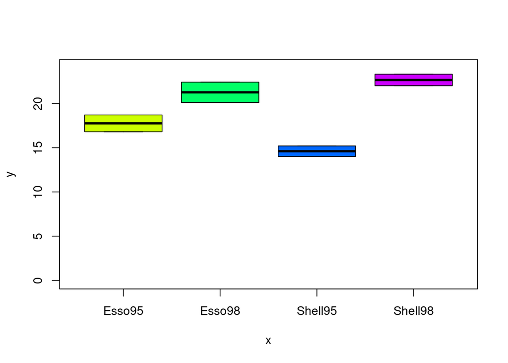

```r
plot(station_fuel, km, col=rainbow(5)[2:5], ylim=c(0,24))
```

and, of course, I can do everything in a fully parametric setting…

```r
# Parametric test:
summary(aov(km ~ station + fuel + station:fuel))
```

```
##              Df Sum Sq Mean Sq F value  Pr(>F)
## station       1   1.53    1.53   1.018 0.37001
## fuel          1  66.70   66.70  44.357 0.00264 **
## station:fuel  1  10.35   10.35   6.884 0.05857 .
## Residuals     4   6.01    1.50
## ---
## Signif. codes:  0 '***' 0.001 '**' 0.01 '*' 0.05 '.' 0.1 ' ' 1
```

```r
# Without interaction
summary.aov(aov(km ~ station + fuel))
```

```
##             Df Sum Sq Mean Sq F value  Pr(>F)
## station      1   1.53    1.53   0.468 0.52440
## fuel         1  66.70   66.70  20.378 0.00632 **
## Residuals    5  16.37    3.27
## ---
## Signif. codes:  0 '***' 0.001 '**' 0.01 '*' 0.05 '.' 0.1 ' ' 1
```

```r
# Without station
summary.aov(aov(km ~ fuel))
```

```
##             Df Sum Sq Mean Sq F value  Pr(>F)
## fuel         1   66.7   66.70   22.36 0.00323 **
## Residuals    6   17.9    2.98
## ---
## Signif. codes:  0 '***' 0.001 '**' 0.01 '*' 0.05 '.' 0.1 ' ' 1
```

**To do everything in a permutational setting, I need to recognize that, actually, the tests that I need to run are more than one!**

The two-way ANOVA full model is:
$$Km = \mu + \alpha_i + \beta_j + \gamma_{ij} + \epsilon$$

So, I need to see if $\gamma=0$, or $\beta=0$ or $\alpha=0$ and, for each of this tests, I have a different permutation scheme.

Let’s start with the
$$H_0:\gamma=0 \; vs \; H_1:\gamma\neq0$$

Which means that the model under $H_1$ is given by:
$$Km = \mu + \alpha_i + \beta_j + \gamma_{ij} + \epsilon$$
And under $H_0$:
$$Km = \mu + \alpha_i + \beta_j + \epsilon$$
, and **permuting the residuals** under this model should yield likelihood-invariant datasets. So, let’s compute the test statistic

```r
summary.aov(aov(km ~ station + fuel + station:fuel))
```

```
##              Df Sum Sq Mean Sq F value  Pr(>F)
## station       1   1.53    1.53   1.018 0.37001
## fuel          1  66.70   66.70  44.357 0.00264 **
## station:fuel  1  10.35   10.35   6.884 0.05857 .
## Residuals     4   6.01    1.50
## ---
## Signif. codes:  0 '***' 0.001 '**' 0.01 '*' 0.05 '.' 0.1 ' ' 1
```

```r
T0_station_fuel <- summary.aov(aov(km ~ station + fuel + station:fuel))[[1]][3,4]  # extract the test statistic
T0_station_fuel
```

```
## [1] 6.883624
```

and compute the permutational distribution. Note that we have to **estimate** the residuals which we will permute.

```r
aov.H0station_fuel <- aov(km ~ station + fuel)
aov.H0station_fuel
```

```
## Call:
##    aov(formula = km ~ station + fuel)
##
## Terms:
##                  station     fuel Residuals
## Sum of Squares   1.53125 66.70125  16.36625
## Deg. of Freedom        1        1         5
##
## Residual standard error: 1.809213
## Estimated effects may be unbalanced
```

```r
residuals.H0station_fuel <- aov.H0station_fuel$residuals # estimate residuals
n = 8


T_station_fuel <- numeric(B)
for(perm in 1:B){
  permutation <- sample(n)
  # permute the residuals
  residuals.H0station_fuel <- residuals.H0station_fuel[permutation]
  km.perm.H0station_fuel <- aov.H0station_fuel$fitted + residuals.H0station_fuel
  # re-fit full model to calculate statistic
  T_station_fuel[perm] <- summary.aov(aov(km.perm.H0station_fuel ~ station + fuel + station:fuel))[[1]][3,4]
}
```

And the p-value…

```r
sum(T_station_fuel >= T0_station_fuel)/B
```

```
## [1] 0.0724
```

Not significant, meaning that I can reduce the model and then perform my test on my main effects.

To test $H_0:\beta=0$ vs $H_1:\beta\neq 0$, I am assuming under $H_0$ the following model $Km = \mu + \alpha_i + \epsilon$, while for $H_0:\alpha=0$ vs $H_1:\alpha\neq0$ I am assuming $Km = \mu + \beta_j + \epsilon$ under $H_0$. That is, in the next code blocks I will perform **two separate tests**.

Again, the idea is to permute the residuals under $H_0$, so let’s compute them.

```r
# Test for station
T0_station <- summary.aov(aov(km ~ station + fuel))[[1]][1,4]
# residuals under H0:
# km = mu + beta*fuel
aov.H0station <- aov(km ~ fuel)
residuals.H0station <- aov.H0station$residuals

# Test for fuel
T0_fuel <- summary.aov(aov(km ~ station + fuel))[[1]][2,4]
# residuals under H0:
# km = mu + alpha*station
aov.H0fuel <- aov(km ~ station)
residuals.H0fuel <- aov.H0fuel$residuals
```

And let’s now compute the permutational distribution, and thus the p-value

```r
# Test both factors in a single loop
B <- 1000
T_fuel <- T_station <- numeric(B)
for(perm in 1:B){
  permutation <- sample(n)

  # Test station
  km.perm.H0station <- aov.H0station$fitted + residuals.H0station[permutation]
  T_station[perm] <- summary.aov(aov(km.perm.H0station ~ station + fuel))[[1]][1,4]

  # Test fuel
  km.perm.H0fuel <- aov.H0fuel$fitted + residuals.H0fuel[permutation]
  T_fuel[perm] <- summary.aov(aov(km.perm.H0fuel ~ station + fuel))[[1]][2,4]
}
```

```r
sum(T_station >= T0_station)/B
```

```
## [1] 0.53
```

```r
sum(T_fuel >= T0_fuel)/B
```

```
## [1] 0.028
```

In histograms

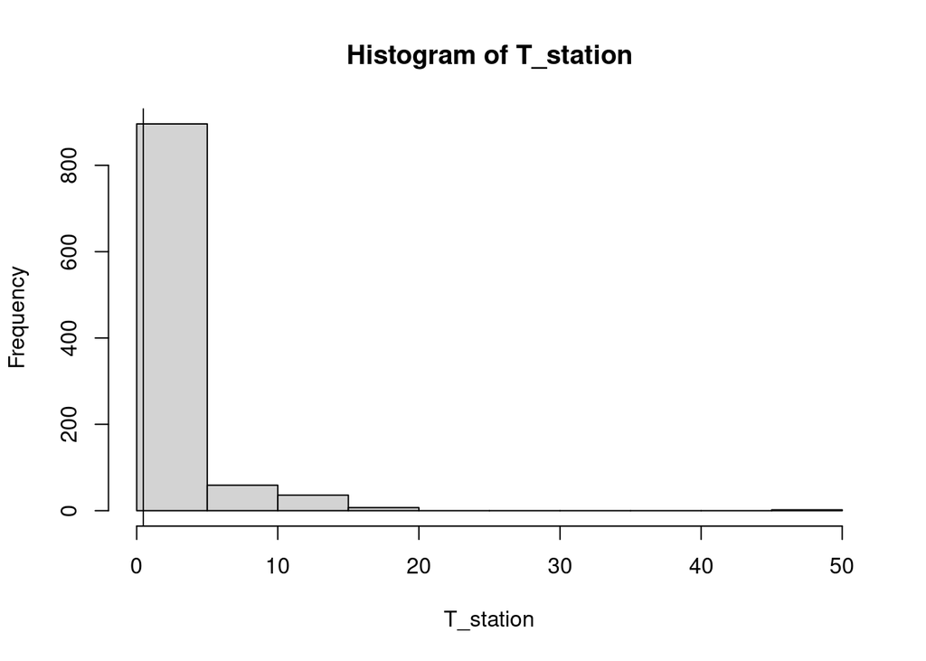

```r
hist(T_station)
abline(v=T0_station)
```

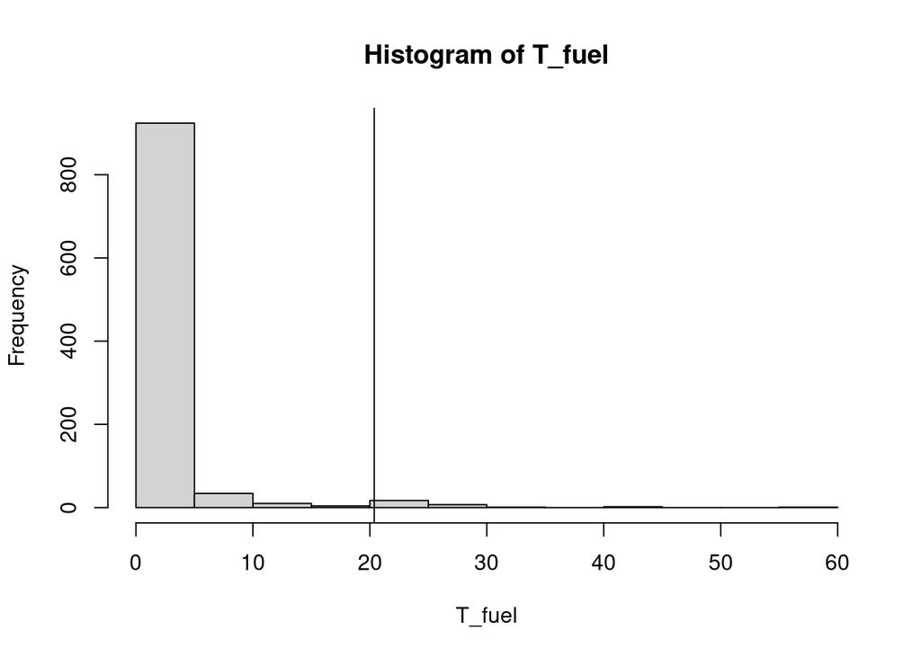

```r
hist(T_fuel)
abline(v=T0_fuel)
```

I can remove station, so let’s go on on testing Fuel… which actually is a one-way ANOVA… Hence, we have our last hypothesis test:
$$H_0: \beta = 0 \implies Km = \mu + \epsilon$$
*versus*
$$H_1: \beta \neq 0 \implies Km = \mu + \beta_j + \epsilon$$
**It can be shown in this case the residual permutation and the data permutation are the same**…

```r
# TEST ON THE FACTOR FUEL
T0_fuel <- summary.aov(aov(km ~  fuel))[[1]][1,4]
# residuals under H0
# km = mu
residuals.H0fuel <- km - M  # subtract global mean

# Note that in this case, permuting the residuals under H0
# and permuting the data is exactly the same:
permutation <- sample(n)
km.perm.H0fuel <- M + residuals.H0fuel[permutation]
km.perm        <- km[permutation]

all.equal(km.perm.H0fuel, km.perm)
```

```
## [1] TRUE
```

```r
T_fuel <- numeric(B)
for(perm in 1:B){
  permutation <- sample(n)
  km.perm <- km[permutation]
  T_fuel[perm] <- summary.lm(aov(km.perm ~ fuel ))$f[1]

}
sum(T_fuel >= T0_fuel)/B
```

```
## [1] 0.006
```

### Multivariate Analysis of Variance

The strategy behind the multivariate analysis of variance is admittedly fairly similar. We use the Iris dataset

```r
data(iris)
attach(iris)
head(iris)
```

|  | Sepal.Length | Sepal.Width | Petal.Length | Petal.Width | Species |
| --- | --- | --- | --- | --- | --- |
| 1 | 5.1 | 3.5 | 1.4 | 0.2 | setosa |
| 2 | 4.9 | 3.0 | 1.4 | 0.2 | setosa |
| 3 | 4.7 | 3.2 | 1.3 | 0.2 | setosa |
| 4 | 4.6 | 3.1 | 1.5 | 0.2 | setosa |
| 5 | 5.0 | 3.6 | 1.4 | 0.2 | setosa |
| 6 | 5.4 | 3.9 | 1.7 | 0.4 | setosa |

```r
table(iris$Species)
```

```
##
##     setosa versicolor  virginica
##         50         50         50
```

let’s arrange it a bit, and plot it.

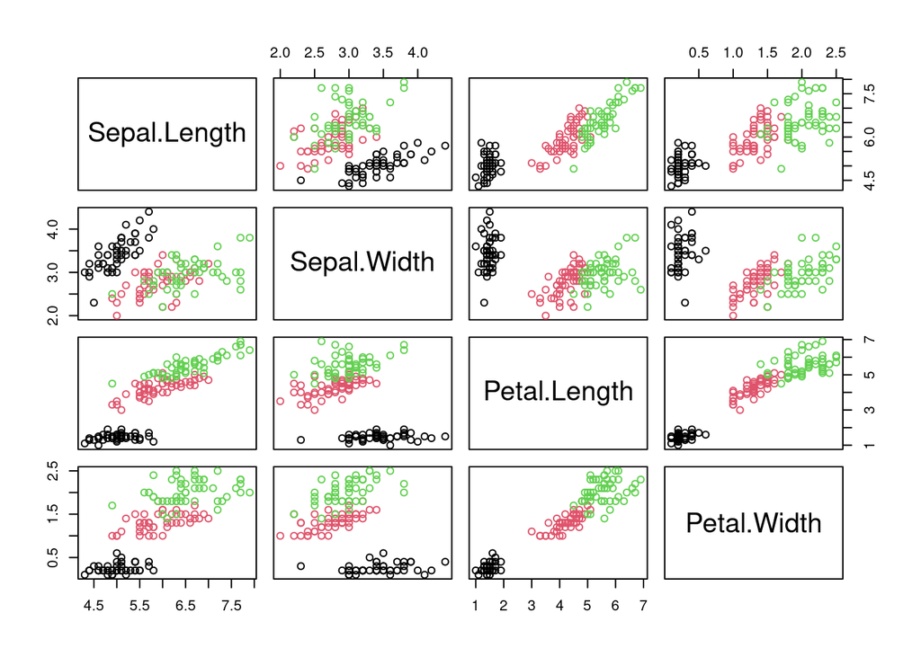

```r
species.name <- factor(Species, labels=c('setosa','versicolor','virginica'))
iris4        <- iris[,1:4]
plot(iris4,col=species.name)
```

```r
i1 <- which(species.name=='setosa')
i2 <- which(species.name=='versicolor')
i3 <- which(species.name=='virginica')
n1 <- length(i1)
n2 <- length(i2)
n3 <- length(i3)
n  <- n1+n2+n3

g  <- length(levels(species.name))
p  <- 4
```

How to perform a MANOVA test? instead of using the F-test, we will develop a test based on a “permutationalisation” of the Wilks[^2] test. Let’s compute the permutational test statistic

```r
fit <- manova(as.matrix(iris4) ~ species.name)
summary.manova(fit,test="Wilks")
```

```
##               Df    Wilks approx F num Df den Df    Pr(>F)
## species.name   2 0.023439   199.15      8    288 < 2.2e-16 ***
## Residuals    147
## ---
## Signif. codes:  0 '***' 0.001 '**' 0.01 '*' 0.05 '.' 0.1 ' ' 1
```

```r
T0 <- -summary.manova(fit,test="Wilks")$stats[1,2]
T0
```

```
## [1] -0.02343863
```

And let’s now compute instead the permutational distribution of the test statistic.

```r
set.seed(seed)
T_stat <- numeric(B)

for(perm in 1:B){
  # choose random permutation
  permutation <- sample(1:n)
  species.name.perm <- species.name[permutation]
  fit.perm <- manova(as.matrix(iris4) ~ species.name.perm)
  T_stat[perm] <- -summary.manova(fit.perm,test="Wilks")$stats[1,2]
}
```

Let’s visualize again the distribution, and the p-value

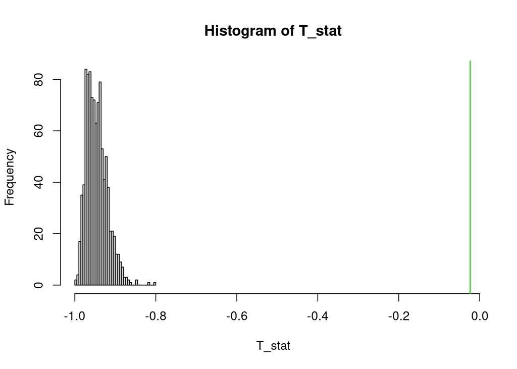

```r
hist(T_stat,xlim=range(c(T_stat,T0)),breaks=30)
abline(v=T0,col=3,lwd=2)
```

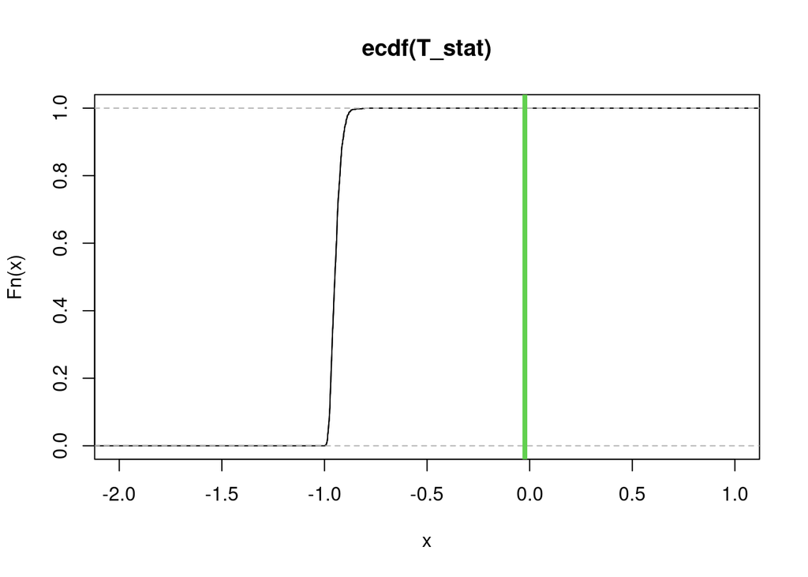

```r
plot(ecdf(T_stat),xlim=c(-2,1))
abline(v=T0,col=3,lwd=4)
```

```r
# p-value
p_val <- sum(T_stat>=T0)/B
p_val
```

```
## [1] 0
```

## Permutational regression: continuous regressors

### Simple regression

We have now seen many applications of permutation testing to various real-world methodological issues… The last one is regression. In this case we will work with some simulated data: specifically data generated from a linear model with a **heavy-tailed error term** (we have seen in **Lab$03$** the effect of heavy tails of a distribution in the *t-test*).

Here is a recap of the algorithm you have studied in the lectures.

**Algorithm 1**: Permutation test algorithm for linear models

1. Set $H_0$ (smaller model) and $H_1$ (more complex model). *E.g.*,
   $$H_1: y_i = \beta_0 + \beta_1 x_{i1} + \epsilon_i$$
   $$H_0: y_i = \beta_0 + \epsilon_i$$
   where the residuals are of an unknown distibution, but we do assume they are i.i.d with $\mathbb{E}[\epsilon]=0$.
2. Fit the full model ($H_1$), and extract the value of test statistic (*e.g.*, the $F$ statistic)
3. Fit the reduced model ($H_0$ )to estimate the residuals, which are exchangeable under $H_0$. Extract as well the fitted values $\hat{y}_i$.
4. Run Conditional Monte Carlo simulation to estimate the permutational distribution of the statistic conditional on the sample. For example, we may have in the $k$ iteration, the $k$ permutational sample, and for each $i$:
   $$y_i^{(k)} = \hat{y}_i + \epsilon_i^{(k)}$$
   Where $\hat{y}_i$ is the fitted value of the reduced model in step ($2$) and $\epsilon_i^{(k)}$ a sample without replacement of the estimated residuals. With such dependent variable, we fit the full model ( *i.e.* the model under $H_1$) and extract $T^{(k)}$, the value of the test statistic in the $k$th iteration )
5. Compare the value of the statistic in ($2$) with the permutational distribution estimated in ($4$) of $T^{(k)}, \; k \in \mathcal{K}$to yield the p-value.

```r
set.seed(seed)
# covariate values
x1 <- runif(n,0,10)

# generating model
b0 <- 2
b1 <- 3
Y <- b0 + b1*x1 + stabledist::rstable(n,1.2,0)  # heavy tailed term
```

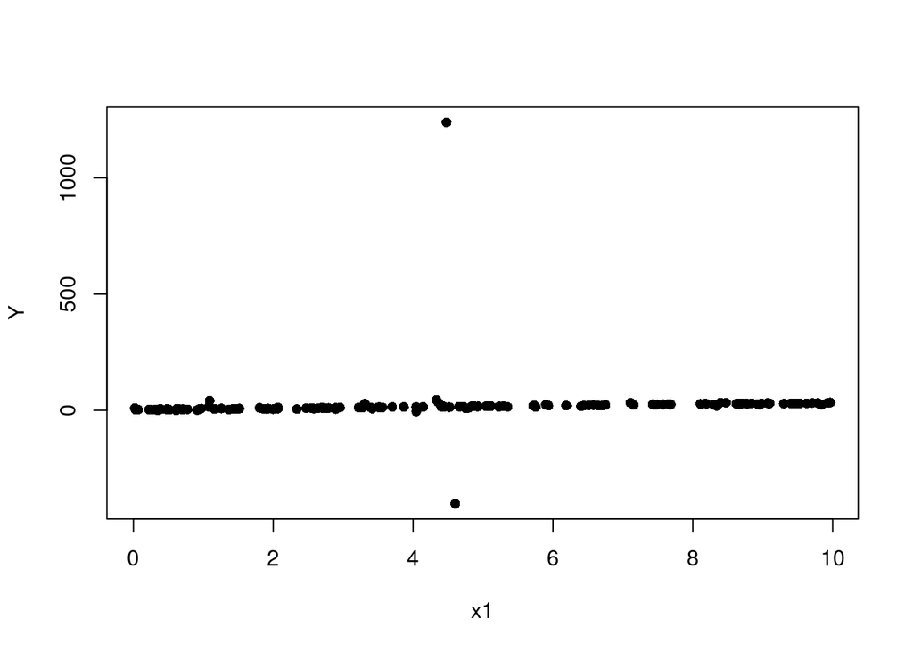

```r
plot(x1,Y,pch=16)
```

```r
# model under H_1
result <- lm(Y ~ x1)
summary(result)
```

```
##
## Call:
## lm(formula = Y ~ x1)
##
## Residuals:
##     Min      1Q  Median      3Q     Max
## -424.13   -7.34   -5.59   -4.05 1218.75
##
## Coefficients:
##             Estimate Std. Error t value Pr(>|t|)
## (Intercept)   10.271     16.305   0.630    0.530
## x1             2.520      2.796   0.901    0.369
##
## Residual standard error: 106.3 on 148 degrees of freedom
## Multiple R-squared:  0.005456,   Adjusted R-squared:  -0.001264
## F-statistic: 0.8119 on 1 and 148 DF,  p-value: 0.369
```

One may ask: why use a nonparametric test?

We test the residuals for normality

```r
shapiro.test(result$residuals)
```

```
##
##  Shapiro-Wilk normality test
##
## data:  result$residuals
## W = 0.11258, p-value < 2.2e-16
```

**Exercise**: show through a DD plot there is no match between the distribution of th (estimated) residuals and a normal one (more on this below).

We proceed by applying **Algorithm 1**.

$$H_0: y_i = \beta_0 + \epsilon_i \,\,\, versus \,\,\,\ H_1: y_1 = \beta_0
+ \beta_1 x_i + \epsilon_i$$

```r
# observed test statistics
T0.beta.sq <- (summary.lm(result)$coefficients[2,1])^2
# in simple regression, same as R squared
# T0.beta <- (summary.lm(result)$r.squared)


T0.beta.std <- (summary.lm(result)$coefficients[2,1] /summary.lm(result)$coefficients[2,2] )^2
# same as
#  (summary.lm(result)$coefficients[2,3])^2
```

```r
model.h0 <- lm(Y ~ 1)
# MC estimation of the permutational distribution of the test statistics
T.beta.sq <- numeric(B)
T.beta.std <- numeric(B)

set.seed(seed)
for(perm in 1:B){
  permutation <- sample(n)
  Y.perm.glob <- model.h0$fitted.values + model.h0$residuals[permutation]
  # alternatively
  # Y.perm.glob <- Y[permutation]
  perm.fit <- lm(Y.perm.glob ~ x1)
  T.beta.sq[perm] <- (summary.lm(perm.fit)$coefficients[2,3])^2
}

sum(T.beta.sq >= T0.beta.sq)/B
```

```
## [1] 0
```

```r
sum(T.beta.std >= T0.beta.std)/B
```

```
## [1] 0
```

### Multiple regression

Now, we have more than one continuous regressor.

```r
# covariate values
x1 <- runif(n,0,10)
x2 <- (1:n)/5
x3 <- rnorm(n,5,5)


# generating model
b0 <- 2
b1 <- 3
b2 <- -2
b3 <- 0
Y <- b0 + b1*x1 + b2*x2 + b3*x3 + stabledist::rstable(n,1.2,0)
```

Let’s run some plots…

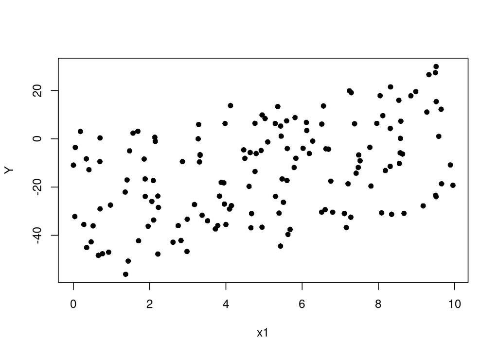

```r
plot(x1,Y,pch=16)
```

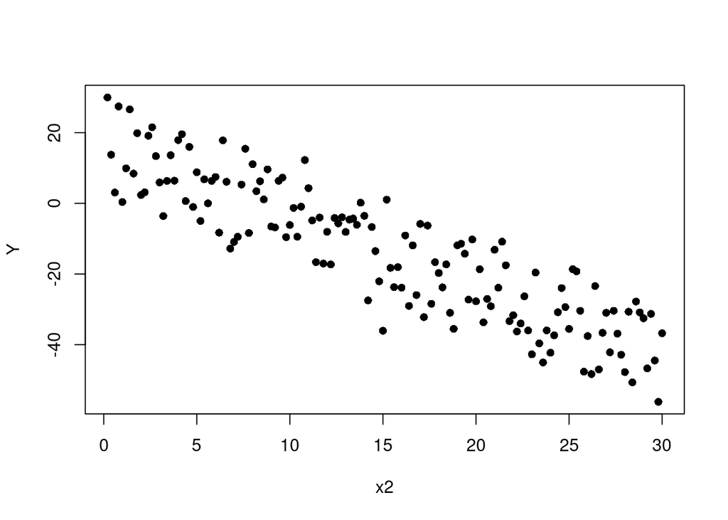

```r
plot(x2,Y,pch=16)
```

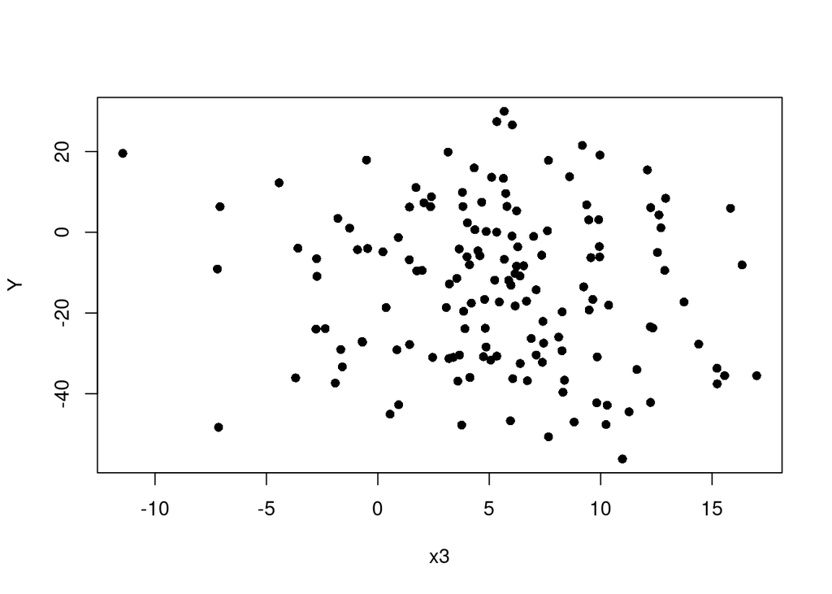

```r
plot(x3,Y,pch=16)
```